# Report_Chapter10

Chiara Huwiler

2023-05-08

## AGDS 10.4 Report Exercises

```r
# Setup
library(tidyverse)
library(recipes)
library(lattice)
library(dplyr)
```

# How well is a model generalisable to a new site?

## Preparing Data

Task: Set aside 20% of the data of each site (Davos and Laegern) for testing.

### Data from Davos

```r
# Load Data
daily_fluxes_davos <- readr::read_csv("./data/FLX_CH-Dav_FLUXNET2015_FULLSET_DD_1997-2014_1-3.csv") |>

  # select only the variables of interested
  dplyr::select(TIMESTAMP,
                GPP_NT_VUT_REF,    # the target
                ends_with("_QC"),  # quality control info
                ends_with("_F"),   # includes all all meteorological covariates
                -contains("JSB")   # useless variable
                ) |>

  # convert to a more sutable date object
  dplyr::mutate(TIMESTAMP = ymd(TIMESTAMP)) |>

  # set all -9999 to NA
  mutate(across(where(is.numeric), ~na_if(., -9999))) |>

  # retain only data based on >=80% good-quality measurements

  # overwrite bad data with NA (without dropping rows)
  dplyr::mutate(GPP_NT_VUT_REF = ifelse(NEE_VUT_REF_QC < 0.8, NA, GPP_NT_VUT_REF),
                TA_F           = ifelse(TA_F_QC        < 0.8, NA, TA_F),
                SW_IN_F        = ifelse(SW_IN_F_QC     < 0.8, NA, SW_IN_F),
                LW_IN_F        = ifelse(LW_IN_F_QC     < 0.8, NA, LW_IN_F),
                VPD_F          = ifelse(VPD_F_QC       < 0.8, NA, VPD_F),
                PA_F           = ifelse(PA_F_QC        < 0.8, NA, PA_F),
                P_F            = ifelse(P_F_QC         < 0.8, NA, P_F),
                WS_F           = ifelse(WS_F_QC        < 0.8, NA, WS_F)) |>

  # drop QC variables (no longer needed)
  dplyr::select(-ends_with("_QC"))
# Data splitting
set.seed(123)
split <- rsample::initial_split(daily_fluxes_davos, prop = 0.8, strata = "VPD_F") # 80% for training, 20% for testing

daily_fluxes_train_dav <- rsample::training(split)
daily_fluxes_test_dav <- rsample::testing(split)
```

### Data Laegern

```r
# Read in data for Laegern site
daily_fluxes_laegern <- readr::read_csv("./data/FLX_CH-Lae_FLUXNET2015_FULLSET_DD_2004-2014_1-4.csv") |>
  # select only the variables we are interested in
  dplyr::select(TIMESTAMP,
                GPP_NT_VUT_REF,    # the target
                ends_with("_QC"),  # quality control info
                ends_with("_F"),   # includes all meteorological covariates
                -contains("JSB")   # weird useless variable
  ) |>
  # convert to a nice date object
  dplyr::mutate(TIMESTAMP = ymd(TIMESTAMP))|>
  # set all -9999 to NA
  mutate(across(where(is.numeric), ~na_if(., -9999))) |>
  # retain only data based on >=80% good-quality measurements
  # overwrite bad data with NA (not dropping rows)
  dplyr::mutate(GPP_NT_VUT_REF = ifelse(NEE_VUT_REF_QC < 0.8, NA, GPP_NT_VUT_REF),
                TA_F           = ifelse(TA_F_QC        < 0.8, NA, TA_F),
                SW_IN_F        = ifelse(SW_IN_F_QC     < 0.8, NA, SW_IN_F),
                LW_IN_F        = ifelse(LW_IN_F_QC     < 0.8, NA, LW_IN_F),
                VPD_F          = ifelse(VPD_F_QC       < 0.8, NA, VPD_F),
                PA_F           = ifelse(PA_F_QC        < 0.8, NA, PA_F),
                P_F            = ifelse(P_F_QC         < 0.8, NA, P_F),
                WS_F           = ifelse(WS_F_QC        < 0.8, NA, WS_F)) |>
# drop QC variables (no longer needed)
  dplyr::select(-ends_with("_QC"))
# Data splitting
set.seed(123)  # for reproducibility
split <- rsample::initial_split(daily_fluxes_laegern, prop = 0.8, strata = "VPD_F")
daily_fluxes_train_lae <- rsample::training(split)
daily_fluxes_test_lae <- rsample::testing(split)
```

## Prediction

Taks: Compare within-site predictions and across-site predictions on the test set for both sites, considering different metrics. For across-site predictions, make sure to implement a train and test setup that enables a true out-of-sample prediction test.

### Within-site prediction Davos

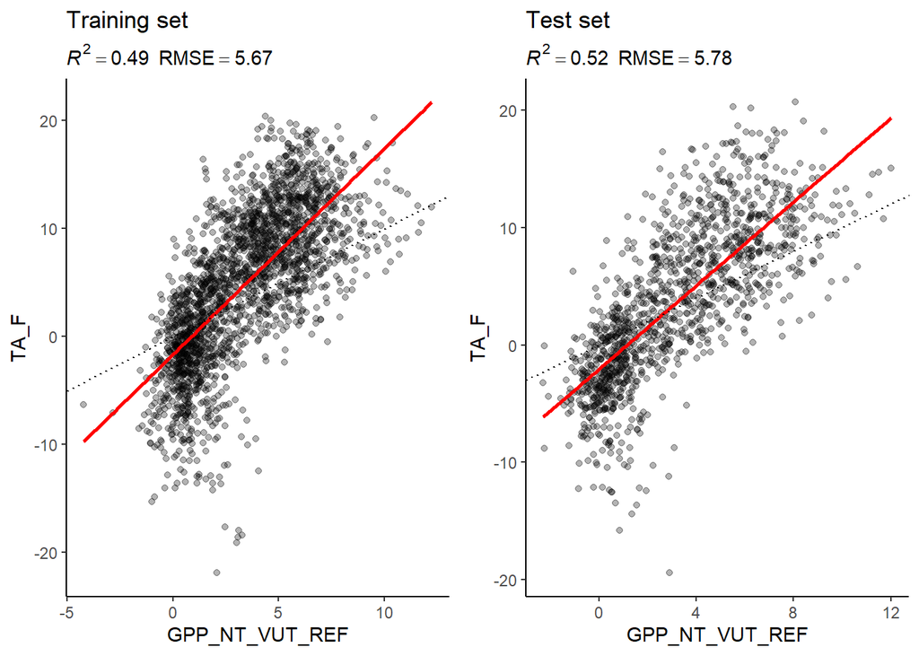

```r
# Fit the linear regression model
mod_lm <- lm(GPP_NT_VUT_REF ~ ., data = daily_fluxes_train_dav)

# make model evaluation into a function to reuse code
eval_model <- function(mod, daily_fluxes_train_dav, daily_fluxes_test_dav){

  # add predictions to the data frames
  daily_fluxes_train_dav <- daily_fluxes_train_dav |>
    drop_na()
  daily_fluxes_train_dav$fitted <- predict(mod, newdata = daily_fluxes_train_dav)

  daily_fluxes_test_dav <- daily_fluxes_test_dav |>
    drop_na()
  daily_fluxes_test_dav$fitted <- predict(mod, newdata = daily_fluxes_test_dav)

  # get metrics tables
  metrics_train <- daily_fluxes_train_dav |>
    yardstick::metrics(GPP_NT_VUT_REF, TA_F)

  metrics_test <- daily_fluxes_test_dav |>
    yardstick::metrics(GPP_NT_VUT_REF, TA_F)

  # extract values from metrics tables
  rmse_train <- metrics_train |>
    filter(.metric == "rmse") |>
    pull(.estimate)
  rsq_train <- metrics_train |>
    filter(.metric == "rsq") |>
    pull(.estimate)

  rmse_test <- metrics_test |>
    filter(.metric == "rmse") |>
    pull(.estimate)
  rsq_test <- metrics_test |>
    filter(.metric == "rsq") |>
    pull(.estimate)

  # visualise as a scatterplot

  # add information of metrics as sub-titles
  plot_1 <- ggplot(data = daily_fluxes_train_dav, aes(GPP_NT_VUT_REF, TA_F)) +
    geom_point(alpha = 0.3) +
    geom_smooth(method = "lm", se = FALSE, color = "red") +
    geom_abline(slope = 1, intercept = 0, linetype = "dotted") +
    labs(subtitle = bquote( italic(R)^2 == .(format(rsq_train, digits = 2)) ~~
                            RMSE == .(format(rmse_train, digits = 3))),
         title = "Training set") +
    theme_classic()

  plot_2 <- ggplot(data = daily_fluxes_test, aes(GPP_NT_VUT_REF, TA_F)) +
    geom_point(alpha = 0.3) +
    geom_smooth(method = "lm", se = FALSE, color = "red") +
    geom_abline(slope = 1, intercept = 0, linetype = "dotted") +
    labs(subtitle = bquote( italic(R)^2 == .(format(rsq_test, digits = 2)) ~~
                            RMSE == .(format(rmse_test, digits = 3))),
         title = "Test set") +
    theme_classic()

  out <- cowplot::plot_grid(plot_1, plot_2)

  return(out)
}
daily_fluxes_train <- daily_fluxes_train_dav
daily_fluxes_test <- daily_fluxes_test_dav

# evaluate linear regression model
eval_model(mod = mod_lm, daily_fluxes_train_dav = daily_fluxes_train, daily_fluxes_test_dav = daily_fluxes_test)
```

### Within-site prediction Laegern

```r
# make model evaluation into a function to reuse code
eval_model <- function(mod, daily_fluxes_train_lae, daily_fluxes_test_lae){

  # add predictions to the data frames
  daily_fluxes_train_lae <- daily_fluxes_train_lae |>
    drop_na()
  daily_fluxes_train_lae$fitted <- predict(mod, newdata = daily_fluxes_train_lae)

  daily_fluxes_test_lae <- daily_fluxes_test_dav |>
    drop_na()
  daily_fluxes_test_lae$fitted <- predict(mod, newdata = daily_fluxes_test_lae)

  # get metrics tables
  metrics_train <- daily_fluxes_train_lae |>
    yardstick::metrics(GPP_NT_VUT_REF, TA_F)

  metrics_test <- daily_fluxes_test_lae |>
    yardstick::metrics(GPP_NT_VUT_REF, TA_F)

  # extract values from metrics tables
  rmse_train <- metrics_train |>
    filter(.metric == "rmse") |>
    pull(.estimate)
  rsq_train <- metrics_train |>
    filter(.metric == "rsq") |>
    pull(.estimate)

  rmse_test <- metrics_test |>
    filter(.metric == "rmse") |>
    pull(.estimate)
  rsq_test <- metrics_test |>
    filter(.metric == "rsq") |>
    pull(.estimate)

  # visualise as a scatterplot

  # add information of metrics as sub-titles
  plot_1 <- ggplot(data = daily_fluxes_train_lae, aes(GPP_NT_VUT_REF, TA_F)) +
    geom_point(alpha = 0.3) +
    geom_smooth(method = "lm", se = FALSE, color = "red") +
    geom_abline(slope = 1, intercept = 0, linetype = "dotted") +
    labs(subtitle = bquote( italic(R)^2 == .(format(rsq_train, digits = 2)) ~~
                            RMSE == .(format(rmse_train, digits = 3))),
         title = "Training set") +
    theme_classic()

  plot_2 <- ggplot(data = daily_fluxes_test_lae, aes(GPP_NT_VUT_REF, TA_F)) +
    geom_point(alpha = 0.3) +
    geom_smooth(method = "lm", se = FALSE, color = "red") +
    geom_abline(slope = 1, intercept = 0, linetype = "dotted") +
    labs(subtitle = bquote( italic(R)^2 == .(format(rsq_test, digits = 2)) ~~
                            RMSE == .(format(rmse_test, digits = 3))),
         title = "Test set") +
    theme_classic()

  out <- cowplot::plot_grid(plot_1, plot_2)

  return(out)
}

# evaluate linear regression model
eval_model(mod = mod_lm, daily_fluxes_train_lae = daily_fluxes_train, daily_fluxes_test_lae = daily_fluxes_test)
```

[output not shown]

### Across-side prediction (true out-of-sample prediction test)

Train on Davos, test on Laegern

```r
# make model evaluation into a function to reuse code
eval_model <- function(mod, daily_fluxes_train_dav, daily_fluxes_test_lae){

  # add predictions to the data frames
  daily_fluxes_train_dav <- daily_fluxes_train_dav |>
    drop_na()
  daily_fluxes_train_dav$fitted <- predict(mod, newdata = daily_fluxes_train_dav)

  daily_fluxes_test_lae <- daily_fluxes_test_dav |>
    drop_na()
  daily_fluxes_test_lae$fitted <- predict(mod, newdata = daily_fluxes_test_lae)

  # get metrics tables
  metrics_train <- daily_fluxes_train_dav |>
    yardstick::metrics(GPP_NT_VUT_REF, TA_F)

  metrics_test <- daily_fluxes_test_lae |>
    yardstick::metrics(GPP_NT_VUT_REF, TA_F)

  # extract values from metrics tables
  rmse_train <- metrics_train |>
    filter(.metric == "rmse") |>
    pull(.estimate)
  rsq_train <- metrics_train |>
    filter(.metric == "rsq") |>
    pull(.estimate)

  rmse_test <- metrics_test |>
    filter(.metric == "rmse") |>
    pull(.estimate)
  rsq_test <- metrics_test |>
    filter(.metric == "rsq") |>
    pull(.estimate)

  # visualise as a scatterplot

  # add information of metrics as sub-titles
  plot_1 <- ggplot(data = daily_fluxes_train_dav, aes(GPP_NT_VUT_REF, TA_F)) +
    geom_point(alpha = 0.3) +
    geom_smooth(method = "lm", se = FALSE, color = "red") +
    geom_abline(slope = 1, intercept = 0, linetype = "dotted") +
    labs(subtitle = bquote( italic(R)^2 == .(format(rsq_train, digits = 2)) ~~
                            RMSE == .(format(rmse_train, digits = 3))),
         title = "Training set") +
    theme_classic()

  plot_2 <- ggplot(data = daily_fluxes_test_lae, aes(GPP_NT_VUT_REF, TA_F)) +
    geom_point(alpha = 0.3) +
    geom_smooth(method = "lm", se = FALSE, color = "red") +
    geom_abline(slope = 1, intercept = 0, linetype = "dotted") +
    labs(subtitle = bquote( italic(R)^2 == .(format(rsq_test, digits = 2)) ~~
                            RMSE == .(format(rmse_test, digits = 3))),
         title = "Test set") +
    theme_classic()

  out <- cowplot::plot_grid(plot_1, plot_2)

  return(out)
}

# evaluate linear regression model
eval_model(mod = mod_lm, daily_fluxes_train_dav = daily_fluxes_train, daily_fluxes_test_lae = daily_fluxes_test)
```

[output not shown]

### Across-side prediction

Train on Laegern, test on Davos

```r
# make model evaluation into a function to reuse code
eval_model <- function(mod, daily_fluxes_train_lae, daily_fluxes_test_dav){

  # add predictions to the data frames
  daily_fluxes_train_lae <- daily_fluxes_train_lae |>
    drop_na()
  daily_fluxes_train_lae$fitted <- predict(mod, newdata = daily_fluxes_train_lae)

  daily_fluxes_test_dav <- daily_fluxes_test_dav |>
    drop_na()
  daily_fluxes_test_dav$fitted <- predict(mod, newdata = daily_fluxes_test_dav)

  # get metrics tables
  metrics_train <- daily_fluxes_train_lae |>
    yardstick::metrics(GPP_NT_VUT_REF, TA_F)

  metrics_test <- daily_fluxes_test_dav |>
    yardstick::metrics(GPP_NT_VUT_REF, TA_F)

  # extract values from metrics tables
  rmse_train <- metrics_train |>
    filter(.metric == "rmse") |>
    pull(.estimate)
  rsq_train <- metrics_train |>
    filter(.metric == "rsq") |>
    pull(.estimate)

  rmse_test <- metrics_test |>
    filter(.metric == "rmse") |>
    pull(.estimate)
  rsq_test <- metrics_test |>
    filter(.metric == "rsq") |>
    pull(.estimate)

  # visualise as a scatterplot

  # add information of metrics as sub-titles
  plot_1 <- ggplot(data = daily_fluxes_train_lae, aes(GPP_NT_VUT_REF, TA_F)) +
    geom_point(alpha = 0.3) +
    geom_smooth(method = "lm", se = FALSE, color = "red") +
    geom_abline(slope = 1, intercept = 0, linetype = "dotted") +
    labs(subtitle = bquote( italic(R)^2 == .(format(rsq_train, digits = 2)) ~~
                            RMSE == .(format(rmse_train, digits = 3))),
         title = "Training set") +
    theme_classic()

  plot_2 <- ggplot(data = daily_fluxes_test_dav, aes(GPP_NT_VUT_REF, TA_F)) +
    geom_point(alpha = 0.3) +
    geom_smooth(method = "lm", se = FALSE, color = "red") +
    geom_abline(slope = 1, intercept = 0, linetype = "dotted") +
    labs(subtitle = bquote( italic(R)^2 == .(format(rsq_test, digits = 2)) ~~
                            RMSE == .(format(rmse_test, digits = 3))),
         title = "Test set") +
    theme_classic()

  out <- cowplot::plot_grid(plot_1, plot_2)

  return(out)
}

# evaluate linear regression model
eval_model(mod = mod_lm, daily_fluxes_train_lae = daily_fluxes_train, daily_fluxes_test_dav = daily_fluxes_test)
```

[output not shown]

## Train a single model

Task: Train a single model with training data pooled from both sites and predict with this single model on the test data of both sites

```r
# Combine data
data_combined <- rbind(daily_fluxes_train_dav, daily_fluxes_train_lae)
```

```r
# Seperate the features
features <- data_combined[, -ncol(data_combined)]
target <- data_combined[, ncol(data_combined)]
```

```r
# Split the data into traning and testing set
set.seed(123)  # for reproducibility
split <- rsample::initial_split(data_combined, prop = 0.8, strata = "VPD_F")
data_combined_train <- rsample::training(split)
data_combined_test <- rsample::testing(split)
```

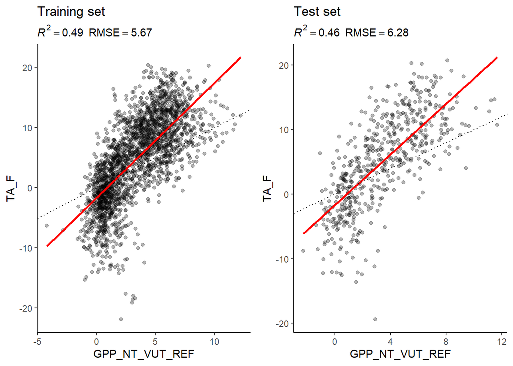

```r
# Train a model on the tranining data
eval_model <- function(mod, data_combined_train, data_combined_test){

  # add predictions to the data frames
  data_combined_train <- data_combined_train |>
    drop_na()
  data_combined_train$fitted <- predict(mod, newdata = data_combined_train)

  data_combined_test <- daily_fluxes_test_dav |>
    drop_na()
  data_combined_test$fitted <- predict(mod, newdata = data_combined_test)

  # get metrics tables
  metrics_train <- data_combined_train |>
    yardstick::metrics(GPP_NT_VUT_REF, TA_F)

  metrics_test <- daily_fluxes_test_lae |>
    yardstick::metrics(GPP_NT_VUT_REF, TA_F)

  # extract values from metrics tables
  rmse_train <- metrics_train |>
    filter(.metric == "rmse") |>
    pull(.estimate)
  rsq_train <- metrics_train |>
    filter(.metric == "rsq") |>
    pull(.estimate)

  rmse_test <- metrics_test |>
    filter(.metric == "rmse") |>
    pull(.estimate)
  rsq_test <- metrics_test |>
    filter(.metric == "rsq") |>
    pull(.estimate)

  # visualise as a scatterplot

  # add information of metrics as sub-titles
  plot_1 <- ggplot(data = data_combined_train, aes(GPP_NT_VUT_REF, TA_F)) +
    geom_point(alpha = 0.3) +
    geom_smooth(method = "lm", se = FALSE, color = "red") +
    geom_abline(slope = 1, intercept = 0, linetype = "dotted") +
    labs(subtitle = bquote( italic(R)^2 == .(format(rsq_train, digits = 2)) ~~
                            RMSE == .(format(rmse_train, digits = 3))),
         title = "Training set") +
    theme_classic()

  plot_2 <- ggplot(data = data_combined_test, aes(GPP_NT_VUT_REF, TA_F)) +
    geom_point(alpha = 0.3) +
    geom_smooth(method = "lm", se = FALSE, color = "red") +
    geom_abline(slope = 1, intercept = 0, linetype = "dotted") +
    labs(subtitle = bquote( italic(R)^2 == .(format(rsq_test, digits = 2)) ~~
                            RMSE == .(format(rmse_test, digits = 3))),
         title = "Test set") +
    theme_classic()

  out <- cowplot::plot_grid(plot_1, plot_2)

  return(out)
}
# evaluate linear regression model
eval_model(mod = mod_lm, data_combined_train = daily_fluxes_train, data_combined_test = daily_fluxes_test)
```

*How do the model metrics on the test set compare to the true out-of-sample setup above?*

*Is it a valid approach to perform model training like this?*

# Characteristics of the two sites

Task: Get information about the characteristics of the two sites. What are the differences in terms of climate, vegetation, altitude, etc. between the Davos and Laegern sites?

- Davos: subalpine coniferous forest
  - climate: mean annual air temperature 4.3 Celsius, mean annual precipitation 1020mm
  - vegetation: coniferous forest, evergreen needleleaf forests
  - altitude: 1639 m a.s.l.
- Laegern
  - climate: mean annual air temperature 8.6 Celsius
  - vegetation: mixed forest
  - altitude: 689 m a.s.l.

*What could be biases of the out-of-sample predictions?*

Climate: The mean annual air temperature is over 4 Celsius higher in Lagern than in Davos. This difference is also mirrored in the photosynthesis and respiration rates of the vegetation.

Vegetation: Also the vegetation is different. As the Davos site is a subalpine coniferous forest, whereas the Laegern site is a mixed forest. The differences in vegetation could lead to differences in the leaf nitrogen content and in leaf penology.

Altitude: There is a big difference in the altitude and so there is also an difference in the atmospheric pressure, temperature (as explicit above) and humidity.

Each of these three differences can lead to different GPP and TA relationships. So model trained on one site may not generalize well to the other site.